# CW1_12711142_A_RUSSELL

# 5.Logistical Regression

```r
library(MASS)
library(ISLR)
fix(Boston)
mdn_crim<-median(Boston$crim)

mcrim<-Boston$crim>mdn_crim
#FALSE-SUBURB HAS CRIME RATE BELOW BOSTON MEDIAN
#TRUE-SUBURB HAS CRIME RATE ABOVE BOSTON MEDIAN

glm.fit<-glm(mcrim~zn+indus+chas+nox+rm+age+dis+rad+tax+ptratio+black+lstat+medv,data=Boston,family = binomial)
summary(glm.fit)
```

```
##
## Call:
## glm(formula = mcrim ~ zn + indus + chas + nox + rm + age + dis +
##     rad + tax + ptratio + black + lstat + medv, family = binomial,
##     data = Boston)
##
## Deviance Residuals:
##     Min       1Q   Median       3Q      Max
## -2.3946  -0.1585  -0.0004   0.0023   3.4239
##
## Coefficients:
##               Estimate Std. Error z value Pr(>|z|)
## (Intercept) -34.103704   6.530014  -5.223 1.76e-07 ***
## zn           -0.079918   0.033731  -2.369  0.01782 *
## indus        -0.059389   0.043722  -1.358  0.17436
## chas          0.785327   0.728930   1.077  0.28132
## nox          48.523782   7.396497   6.560 5.37e-11 ***
## rm           -0.425596   0.701104  -0.607  0.54383
## age           0.022172   0.012221   1.814  0.06963 .
## dis           0.691400   0.218308   3.167  0.00154 **
## rad           0.656465   0.152452   4.306 1.66e-05 ***
## tax          -0.006412   0.002689  -2.385  0.01709 *
## ptratio       0.368716   0.122136   3.019  0.00254 **
## black        -0.013524   0.006536  -2.069  0.03853 *
## lstat         0.043862   0.048981   0.895  0.37052
## medv          0.167130   0.066940   2.497  0.01254 *
## ---
## Signif. codes:  0 '***' 0.001 '**' 0.01 '*' 0.05 '.' 0.1 ' ' 1
##
## (Dispersion parameter for binomial family taken to be 1)
##
##     Null deviance: 701.46  on 505  degrees of freedom
## Residual deviance: 211.93  on 492  degrees of freedom
## AIC: 239.93
##
## Number of Fisher Scoring iterations: 9
```

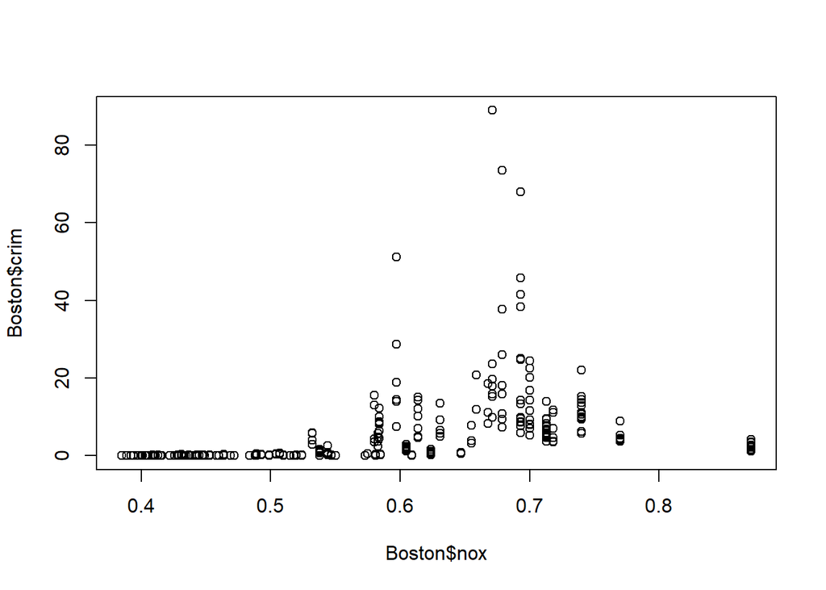

```r
#The two predictors with the smallest P values are:
#nox,nitrogen oxides concentration (parts per 10 million) @ 5.37e-11
#rad, index of accessibility to radial highways @ 1.66e-05
#This suggests that there is a relationship between [nox, rad] and the probability of
#of a suburb have a crime rate above or below the median across the city of boston.

#The postive coefficient for nox suggests that as the suburban concentration of nitrogen oxides increases,
#so to does probability that the suburban crime rate will be above the Boston crime rate median.
plot(Boston$nox,Boston$crim)
```

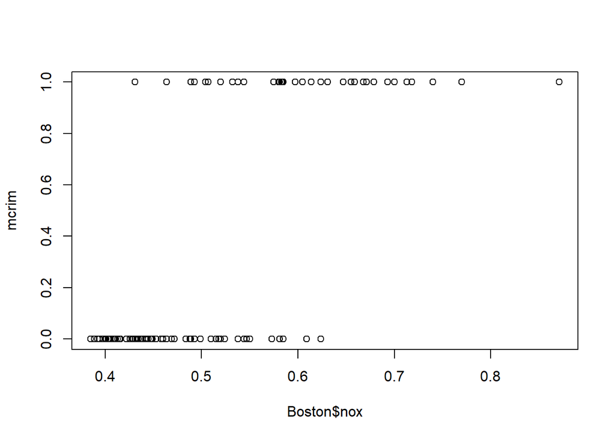

```r
plot(Boston$nox,mcrim)
```

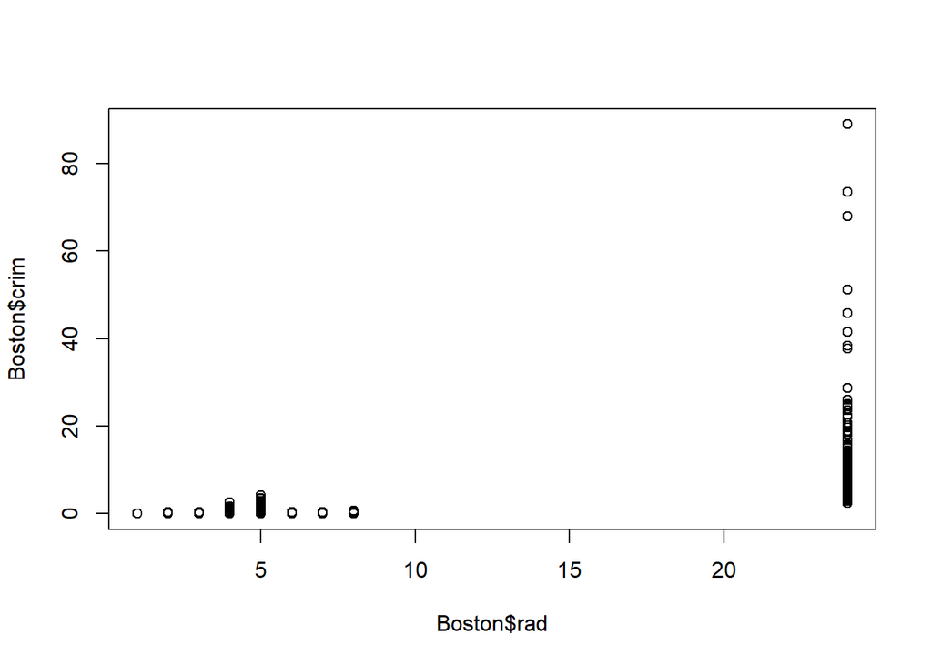

```r
#The postive coefficient for rad suggests that as the suburban index of accessibility to radial highways increases,
#so to does probability that the suburban crime rate will be above the Boston crime rate median.
plot(Boston$rad,Boston$crim)
```

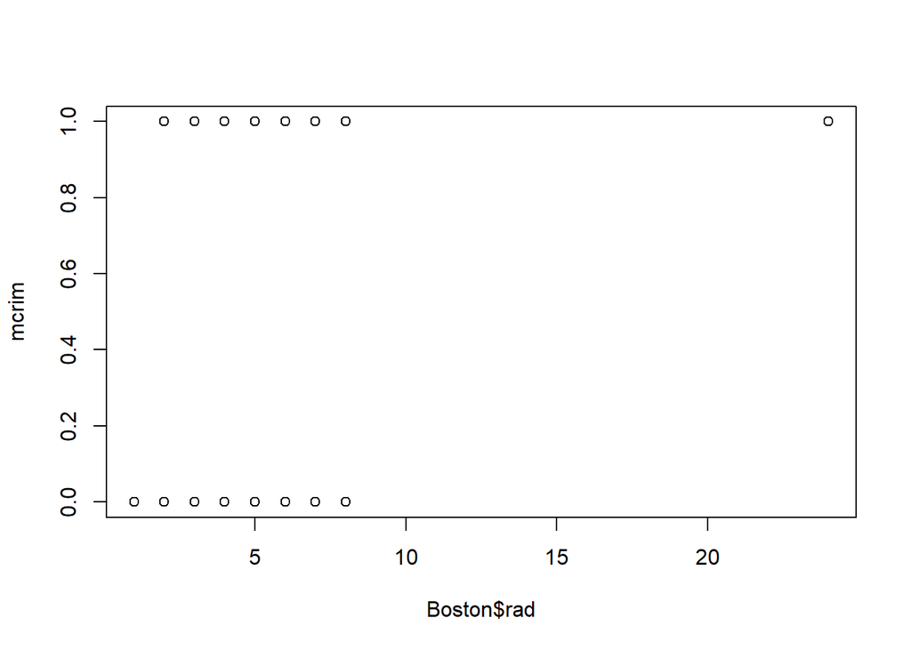

```r
plot(Boston$rad,mcrim)
```

```r
#we now compare the accuracy of logistical regression model with all the predictors against
#a corrected with just the nox and rad predictors both using the training data set

glm.probs<-predict(glm.fit,type = "response")
glm.pred<-rep(FALSE,506)
glm.pred[glm.probs>.5]<-TRUE
table(glm.pred,mcrim)
```

```
##         mcrim
## glm.pred FALSE TRUE
##    FALSE   234   24
##    TRUE     19  229
```

```r
(234+229)/506
```

```
## [1] 0.9150198
```

```r
#The logistical regression model with all the Boston data set predictors was found to have an accuracy of 91.5%
#in predicting if a suburb had a crime rate above the Boston city median

#We now remove all predictors except nox and rad
glm.fit2<-glm(mcrim~nox+rad,data=Boston,family = binomial)
summary(glm.fit2)
```

```
##
## Call:
## glm(formula = mcrim ~ nox + rad, family = binomial, data = Boston)
##
## Deviance Residuals:
##      Min        1Q    Median        3Q       Max
## -1.96118  -0.35325  -0.02796   0.00708   2.55398
##
## Coefficients:
##              Estimate Std. Error z value Pr(>|z|)
## (Intercept) -17.73622    1.90516  -9.310  < 2e-16 ***
## nox          28.02689    3.18112   8.810  < 2e-16 ***
## rad           0.50314    0.09941   5.061 4.17e-07 ***
## ---
## Signif. codes:  0 '***' 0.001 '**' 0.01 '*' 0.05 '.' 0.1 ' ' 1
##
## (Dispersion parameter for binomial family taken to be 1)
##
##     Null deviance: 701.46  on 505  degrees of freedom
## Residual deviance: 265.36  on 503  degrees of freedom
## AIC: 271.36
##
## Number of Fisher Scoring iterations: 8
```

```r
glm.probs2<-predict(glm.fit2,type = "response")
glm.pred2<-rep(FALSE,506)
glm.pred2[glm.probs2>.5]<-TRUE
table(glm.pred2,mcrim)
```

```
##          mcrim
## glm.pred2 FALSE TRUE
##     FALSE   229   44
##     TRUE     24  209
```

```r
(229+209)/506
```

```
## [1] 0.8656126
```

```r
#The logistical regression model with just the nox and rad predictors from the Boston data set predictors was found to have an accuracy of 86.6%
#in predicting if a suburb had a crime rate above the Boston city median which when compared to full
#predictor model demonstrates that most of the accuracy is driven by the these two predictors
```

# 6. Resampling Methods

The standard deviation of a particular statistical learning method is the mean squared error (MSE) of the responses when the model is tested with observations that were not used for training. The MSE is estimated using Cross validation techniques where by portions of training data are held out from model training to be used for testing instead. The MSE will vary depending on the samples drawn for testing so the apportioning, training and testing process is performed multiple times and the total MSE averaged out. Leave one out cross validation LOOCV apportions a single observation so the number of cycles performed is the same number as the sample size. K-fold cross validation divides the data into *k* number of parts so the number of cycles performed is the same number as *k*.

# 7. Resampling Methods

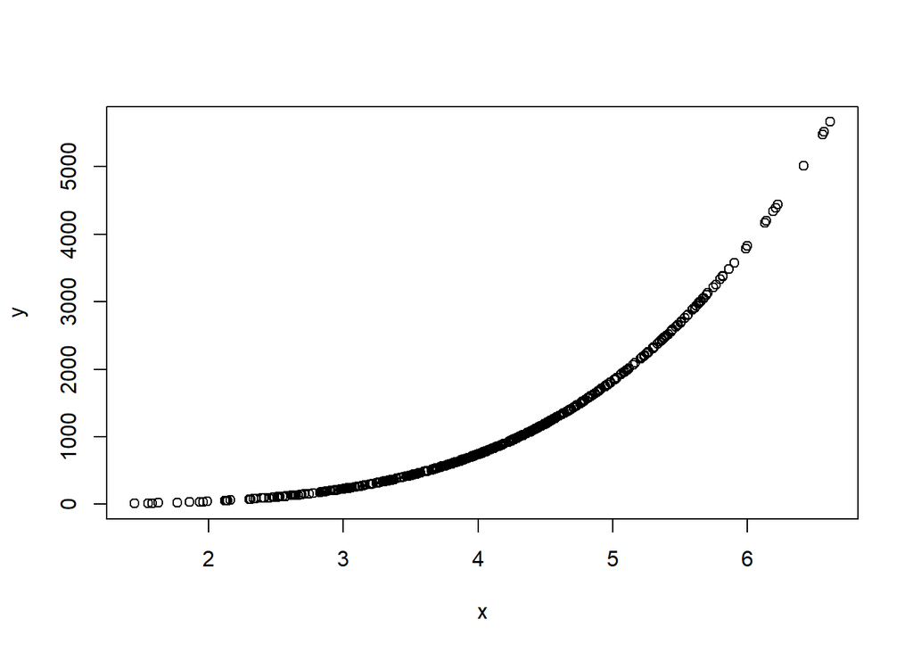

```r
#(a)
set.seed(500)
y = rnorm(500)
x = 4 - rnorm(500)
y = x - 2*x^2 + 3*x^4 + rnorm(500)

#n is the sample size which is 500
#p is the number of preditors which is 1 in this case, x. The model is a quartic polynomial

#(b)
plot(x,y)
```

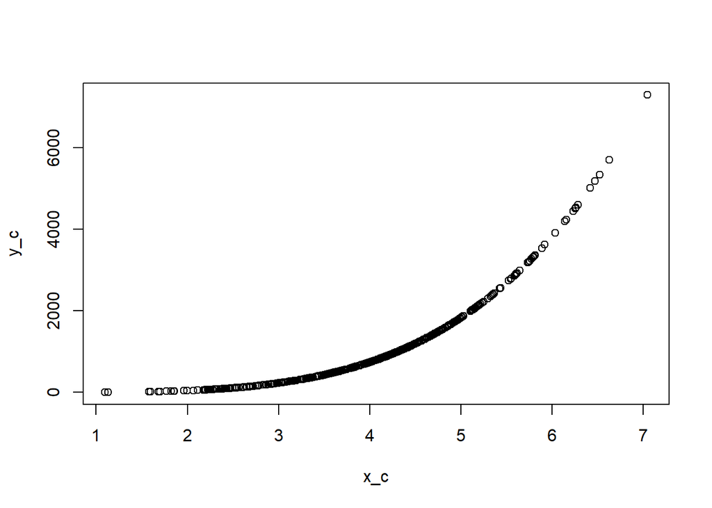

```r
#This dataset demonstrates a strong positive correlation with low irreducible error. A simple linear regression model
#for prediction would suffer from high bias as it would fail to caputure the 4th degree polynomial curve
#of the true underlying model. There for a more flexible model is recommended.

#(c)
library(boot)
set.seed(23)
y_c = rnorm(500)
x_c = 4 - rnorm(500)
y_c = x_c - 2*x_c^2 + 3*x_c^4 + rnorm(500)
plot(x_c,y_c)
```

```r
Q7_c<-data.frame(x_c,y_c)

cv.err.c1=rep(0,4)
CV.err.c2=rep(0,4)

for (i in 1:4) { #LOOCV & K-FOLD loop
  glm.fit.c<-glm(y_c~poly(x_c,i),data=Q7_c)
  cv.err.c1[i] <- cv.glm(Q7_c,glm.fit.c)$delta[1]
  CV.err.c2[i] <- cv.glm(Q7_c,glm.fit.c,K=10)$delta[1]
}

cv.err.c1
```

```
## [1] 1.953373e+05 1.186541e+04 1.514818e+02 1.046784e+00
```

```r
CV.err.c2
```

```
## [1] 1.933147e+05 1.201845e+04 1.578909e+02 1.059236e+00
```

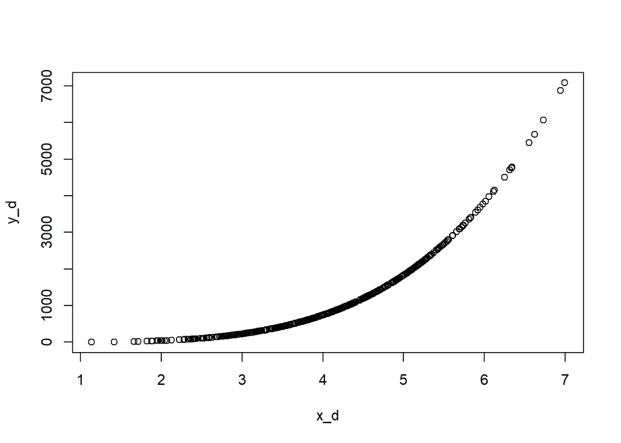

```r
#(d)
library(boot)
set.seed(46)
y_d = rnorm(500)
x_d = 4 - rnorm(500)
y_d = x_d - 2*x_d^2 + 3*x_d^4 + rnorm(500)
plot(x_d,y_d)
```

```r
Q7_d<-data.frame(x_d,y_d)

cv.err.d1=rep(0,4)
CV.err.d2=rep(0,4)

for (i in 1:4) { #LOOCV & K-FOLD loop
  glm.fit.d<-glm(y_d~poly(x_d,i),data=Q7_d)
  cv.err.d1[i] <- cv.glm(Q7_d,glm.fit.d)$delta[1]
  CV.err.d2[i] <- cv.glm(Q7_d,glm.fit.d,K=10)$delta[1]
  print(summary(glm.fit.d))
}
```

```
##
## Call:
## glm(formula = y_d ~ poly(x_d, i), data = Q7_d)
##
## Deviance Residuals:
##    Min      1Q  Median      3Q     Max
## -349.0  -301.3  -167.8   144.4  3183.9
##
## Coefficients:
##              Estimate Std. Error t value Pr(>|t|)
## (Intercept)   1091.75      20.45   53.39   <2e-16 ***
## poly(x_d, i) 21817.73     457.24   47.72   <2e-16 ***
## ---
## Signif. codes:  0 '***' 0.001 '**' 0.01 '*' 0.05 '.' 0.1 ' ' 1
##
## (Dispersion parameter for gaussian family taken to be 209070.5)
##
##     Null deviance: 580130424  on 499  degrees of freedom
## Residual deviance: 104117107  on 498  degrees of freedom
## AIC: 7548.1
##
## Number of Fisher Scoring iterations: 2
##
##
## Call:
## glm(formula = y_d ~ poly(x_d, i), data = Q7_d)
##
## Deviance Residuals:
##     Min       1Q   Median       3Q      Max
## -778.70   -70.31     8.29    65.79   839.64
##
## Coefficients:
##                Estimate Std. Error t value Pr(>|t|)
## (Intercept)    1091.746      4.846  225.30   <2e-16 ***
## poly(x_d, i)1 21817.729    108.355  201.35   <2e-16 ***
## poly(x_d, i)2  9913.722    108.355   91.49   <2e-16 ***
## ---
## Signif. codes:  0 '***' 0.001 '**' 0.01 '*' 0.05 '.' 0.1 ' ' 1
##
## (Dispersion parameter for gaussian family taken to be 11740.89)
```

[output cut: 42 more lines]

```
## (Intercept)   1.092e+03  4.541e-02 24041.6   <2e-16 ***
## poly(x_d, i)1 2.182e+04  1.015e+00 21486.5   <2e-16 ***
## poly(x_d, i)2 9.914e+03  1.015e+00  9763.2   <2e-16 ***
## poly(x_d, i)3 2.404e+03  1.015e+00  2367.9   <2e-16 ***
## poly(x_d, i)4 2.313e+02  1.015e+00   227.8   <2e-16 ***
## ---
## Signif. codes:  0 '***' 0.001 '**' 0.01 '*' 0.05 '.' 0.1 ' ' 1
##
## (Dispersion parameter for gaussian family taken to be 1.031068)
##
##     Null deviance: 5.8013e+08  on 499  degrees of freedom
## Residual deviance: 5.1038e+02  on 495  degrees of freedom
## AIC: 1441.2
##
## Number of Fisher Scoring iterations: 2
```

```r
cv.err.d1
```

```
## [1] 2.127897e+05 1.264620e+04 1.341499e+02 1.046861e+00
```

```r
CV.err.d2
```

```
## [1] 2.121912e+05 1.310631e+04 1.373447e+02 1.057726e+00
```

```r
#As expected, the predicted test MSE's for the models generated with the two different datasets from the
#same true underlying model were found to have negligible difference. As both samples are of the same size,
#we expect the amount of bias and variance in each order of model to be the same no matter what the
#sample is used for training.


#(e) For part (c), the model with the lowest LOOCV and K-FOLD CV errors was iv. QUARTIC MODEL which
# which we would expect given that the true underlying function is QUARTIC

#(f) Upon reviewing the summarys of each model in part (c), we can see that the coefficients
#for the iv. quartic term have the lowest standard deviations which agree with the conclusions
#drawn in (e) that it is the most accurate model.
```

[output not shown]